# experiment1

zhe&yifan

2021/11/2

```r
options(scipen=999)
library(tidyverse)
library("xlsx")
library(ggthemes)
```

```r
free_listing<- read.xlsx('data_1.xlsx',sheetIndex=1)
free_listing
```

```
##      Colours Colour.category Tastes Tastes.Category    Smells Smells.category
## 1      green Domain-specific   sour Domain-specific    stinky Domain-specific
## 2       blue Domain-specific  sweet Domain-specific    smelly Domain-specific
## 3        red Domain-specific  salty Domain-specific    smelly Domain-specific
## 4     yellow Domain-specific bitter Domain-specific  fragrant      Evaluative
## 5      green Domain-specific  sweet Domain-specific irriating     Evaluative
## 6        red Domain-specific  spicy Domain-specific    stinky Domain-specific
## 7       blue Domain-specific   sour Domain-specific    stinky Domain-specific
## 8     orange Domain-specific  salty Domain-specific      sour           Other
## 9       grey Domain-specific bitter Domain-specific     spicy           Other
## 10     white Domain-specific  sweet Domain-specific irriating     Evaluative
## 11     black Domain-specific  spicy Domain-specific   flowery    Source-based
## 12      pink Domain-specific   sour Domain-specific    smelly Domain-specific
## 13       red Domain-specific  salty Domain-specific    stinky Domain-specific
## 14      blue Domain-specific  bland      Evaluative    rotten     Evaluative
```

[output cut: 110 more lines]

```r
free_listing<-data.frame(lapply(free_listing, function(v) {
  if (is.character(v)) return(tolower(v))
  else return(v)
}))
free_listing
```

```
##      Colours Colour.category Tastes Tastes.Category    Smells Smells.category
## 1      green domain-specific   sour domain-specific    stinky domain-specific
## 2       blue domain-specific  sweet domain-specific    smelly domain-specific
## 3        red domain-specific  salty domain-specific    smelly domain-specific
## 4     yellow domain-specific bitter domain-specific  fragrant      evaluative
## 5      green domain-specific  sweet domain-specific irriating     evaluative
## 6        red domain-specific  spicy domain-specific    stinky domain-specific
## 7       blue domain-specific   sour domain-specific    stinky domain-specific
## 8     orange domain-specific  salty domain-specific      sour           other
## 9       grey domain-specific bitter domain-specific     spicy           other
## 10     white domain-specific  sweet domain-specific irriating     evaluative
## 11     black domain-specific  spicy domain-specific   flowery    source-based
## 12      pink domain-specific   sour domain-specific    smelly domain-specific
## 13       red domain-specific  salty domain-specific    stinky domain-specific
## 14      blue domain-specific  bland      evaluative    rotten     evaluative
```

[output cut: 110 more lines]

```r
taste_smell<-free_listing%>%select(!Colours&!Colour.category)
taste_smell
```

```
##     Tastes Tastes.Category    Smells Smells.category
## 1     sour domain-specific    stinky domain-specific
## 2    sweet domain-specific    smelly domain-specific
## 3    salty domain-specific    smelly domain-specific
## 4   bitter domain-specific  fragrant      evaluative
## 5    sweet domain-specific irriating     evaluative
## 6    spicy domain-specific    stinky domain-specific
## 7     sour domain-specific    stinky domain-specific
## 8    salty domain-specific      sour           other
## 9   bitter domain-specific     spicy           other
## 10   sweet domain-specific irriating     evaluative
## 11   spicy domain-specific   flowery    source-based
## 12    sour domain-specific    smelly domain-specific
## 13   salty domain-specific    stinky domain-specific
## 14   bland      evaluative    rotten     evaluative
```

[output cut: 110 more lines]

```r
taste_domain_specific<-taste_smell%>%select(Tastes,Tastes.Category)%>%filter(Tastes.Category=="domain-specific")%>%group_by(Tastes)%>%summarise(fre=length(Tastes))%>%arrange(desc(fre))
taste_domain_specific
```

```
## # A tibble: 6 x 2
##   Tastes   fre
##   <chr>  <int>
## 1 bitter    12
## 2 sour      12
## 3 salty     11
## 4 spicy      9
## 5 sweet      9
## 6 hot        3
```

```r
smell_domain_specific<-taste_smell%>%select(Smells,Smells.category)%>%filter(Smells.category=="domain-specific")%>%group_by(Smells)%>%summarise(fre=length(Smells))%>%arrange(desc(fre))
smell_domain_specific
```

```
## # A tibble: 2 x 2
##   Smells   fre
##   <chr>  <int>
## 1 stinky     7
## 2 smelly     6
```

```r
colour_total<-data.frame(t(c("colour",length(free_listing$Colours[!is.na(free_listing$Colours)]))))
taste_total<-data.frame(t(c("taste",length(free_listing$Tastes[!is.na(free_listing$Tastes)]))))
smell_total<-data.frame(t(c("smell",length(free_listing$Smells[!is.na(free_listing$Smells)]))))
data_total<-rbind(colour_total,taste_total,smell_total)%>%mutate(class="total_n_term")

colour_unique<-data.frame(t(c("colour",length(unique(free_listing$Colours[!is.na(free_listing$Colours)])))))
taste_unique<-data.frame(t(c("taste",length(unique(free_listing$Tastes[!is.na(free_listing$Tastes)])))))
smell_unique<-data.frame(t(c("smell",length(unique(free_listing$Smells[!is.na(free_listing$Smells)])))))
data_unique<-rbind(colour_unique,taste_unique,smell_unique)%>%mutate(class="unique_n_term")
all<-rbind(data_total,data_unique)
all<-all%>%rename("type"=X1)%>%rename("number"=X2)
all$number<-as.numeric(all$number)
all
```

```
##     type number         class
## 1 colour    124  total_n_term
## 2  taste     72  total_n_term
## 3  smell     50  total_n_term
## 4 colour     23 unique_n_term
## 5  taste     13 unique_n_term
## 6  smell     16 unique_n_term
```

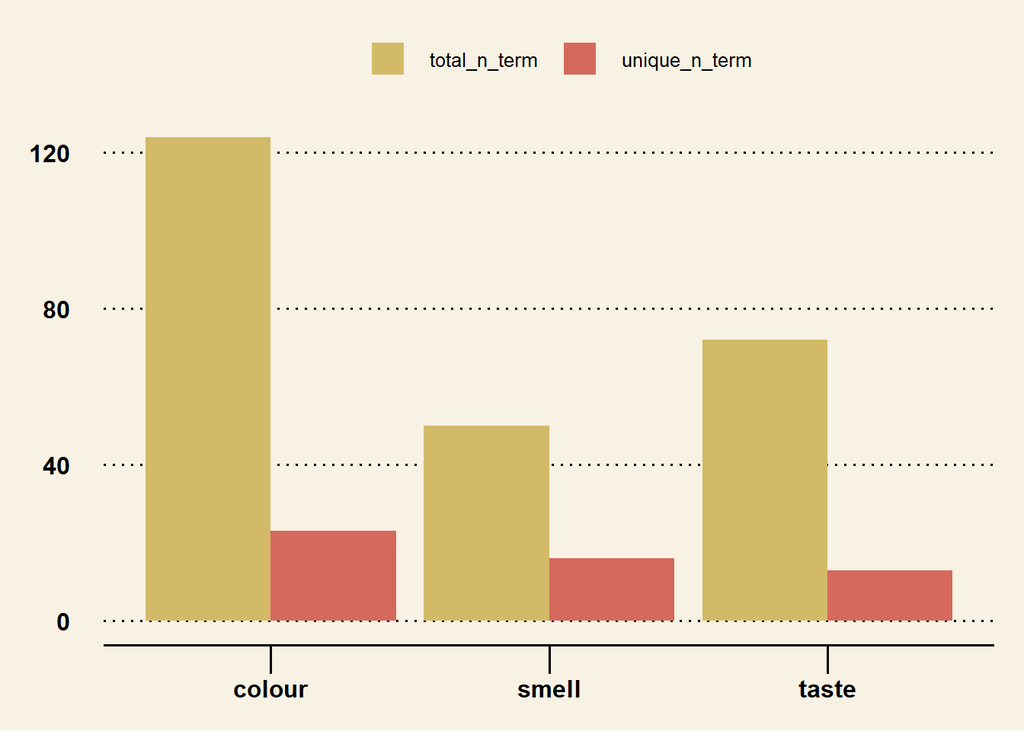

```r
ggplot(all,aes(type,number,fill=class))+geom_bar(stat="identity",position="dodge")+theme_wsj()+
scale_fill_wsj("rgby", "")+
theme(axis.ticks.length=unit(0.5,'cm'))+
guides(fill=guide_legend(title=NULL))
```

We can infer that it’s much easier for international students to come up with colour words, while a bit harder for them to come up with smell and taste words. I guess regluar words for smell and taste are not many.(Here I just listed total terms people listed per domain,not on average)

```r
colour_selected<-free_listing%>%filter(Colour.category=="domain-specific")
colour_selected2<-free_listing%>%filter(Colour.category=="source-based")
colour_selected3<-free_listing%>%filter(Colour.category=="evaluative")
colour_selected4<-free_listing%>%filter(Colour.category=="other")

colour_domain_specific_total<-length(colour_selected$Colours[!is.na(colour_selected$Colours)])
colour_domain_specific_unique<-length(unique(colour_selected$Colours[!is.na(colour_selected$Colours)]))

colour_source_total<-length(colour_selected2$Colours[!is.na(colour_selected2$Colours)])
colour_source_unique<-length(unique(colour_selected2$Colours[!is.na(colour_selected2$Colours)]))

colour_evaluative_total<-length(colour_selected3$Colours[!is.na(colour_selected3$Colours)])
colour_evaluative_unique<-length(unique(colour_selected3$Colours[!is.na(colour_selected3$Colours)]))

colour_other_total<-length(colour_selected4$Colours[!is.na(colour_selected4$Colours)])
colour_other_unique<-length(unique(colour_selected4$Colours[!is.na(colour_selected4$Colours)]))

colour_ration_total<-data.frame(t(c("colour",colour_domain_specific_total/colour_source_total/colour_evaluative_total/colour_other_total)))%>%mutate(class="total")
colour_ration_total<-colour_ration_total%>%rename("type"=X1)%>%rename("number"=X2)
colour_ration_total$number<-as.numeric(colour_ration_total$number)

colour_ration_unique<-data.frame(t(c("colour",colour_domain_specific_unique/colour_source_unique/colour_evaluative_unique/colour_other_unique)))%>%mutate(class="unique")
colour_ration_unique<-colour_ration_unique%>%rename("type"=X1)%>%rename("number"=X2)
colour_ration_unique$number<-as.numeric(colour_ration_unique$number)

colour_ration_total
```

```
##     type    number class
## 1 colour 0.9636364 total
```

```r
colour_ration_unique
```

```
##     type   number  class
## 1 colour 2.833333 unique
```

```r
taste_selected<-free_listing%>%filter(Tastes.Category=="domain-specific")
taste_selected2<-free_listing%>%filter(Tastes.Category=="source-based")
taste_selected3<-free_listing%>%filter(Tastes.Category=="evaluative")
taste_selected4<-free_listing%>%filter(Tastes.Category=="other")

taste_domain_specific_total<-length(taste_selected$Tastes[!is.na(taste_selected$Tastes)])
taste_domain_specific_unique<-length(unique(taste_selected$Tastes[!is.na(taste_selected$Tastes)]))

taste_source_total<-length(taste_selected2$Tastes[!is.na(taste_selected2$Tastes)])
taste_source_unique<-length(unique(taste_selected2$Tastes[!is.na(taste_selected2$Tastes)]))

taste_evaluative_total<-length(taste_selected3$Tastes[!is.na(taste_selected3$Tastes)])
taste_evaluative_unique<-length(unique(taste_selected3$Tastes[!is.na(taste_selected3$Tastes)]))

taste_other_total<-length(taste_selected4$Tastes[!is.na(taste_selected4$Tastes)])
taste_other_unique<-length(unique(taste_selected4$Tastes[!is.na(taste_selected4$Tastes)]))

taste_ration_total<-data.frame(t(c("taste",taste_domain_specific_total/taste_source_total/taste_evaluative_total/taste_other_total)))%>%mutate(class="total")
taste_ration_total<-taste_ration_total%>%rename("type"=X1)%>%rename("number"=X2)
taste_ration_total$number<-as.numeric(taste_ration_total$number)

taste_ration_unique<-data.frame(t(c("taste",taste_domain_specific_unique/taste_source_unique/taste_evaluative_unique/taste_other_unique)))%>%mutate(class="unique")
taste_ration_unique<-taste_ration_unique%>%rename("type"=X1)%>%rename("number"=X2)
taste_ration_unique$number<-as.numeric(taste_ration_unique$number)

taste_ration_total
```

```
##    type    number class
## 1 taste 0.6666667 total
```

```r
taste_ration_unique
```

```
##    type number  class
## 1 taste      1 unique
```

```r
smell_selected<-free_listing%>%filter(Smells.category=="domain-specific")
smell_selected2<-free_listing%>%filter(Smells.category=="source-based")
smell_selected3<-free_listing%>%filter(Smells.category=="evaluative")
smell_selected4<-free_listing%>%filter(Smells.category=="other")

smell_domain_specific_total<-length(smell_selected$Smells[!is.na(smell_selected$Smells)])
smell_domain_specific_unique<-length(unique(smell_selected$Smells[!is.na(smell_selected$Smells)]))

smell_source_total<-length(smell_selected2$Smells[!is.na(smell_selected2$Smells)])
smell_source_unique<-length(unique(smell_selected2$Smells[!is.na(smell_selected2$Smells)]))

smell_evaluative_total<-length(smell_selected3$Smells[!is.na(smell_selected3$Smells)])
smell_evaluative_unique<-length(unique(smell_selected3$Smells[!is.na(smell_selected3$Smells)]))

smell_other_total<-length(smell_selected4$Smells[!is.na(smell_selected4$Smells)])
smell_other_unique<-length(unique(smell_selected4$Smells[!is.na(smell_selected4$Smells)]))

smell_ration_total<-data.frame(t(c("smell",smell_domain_specific_total/smell_source_total/smell_evaluative_total/smell_other_total)))%>%mutate(class="total")
smell_ration_total<-smell_ration_total%>%rename("type"=X1)%>%rename("number"=X2)
smell_ration_total$number<-as.numeric(smell_ration_total$number)

smell_ration_unique<-data.frame(t(c("smell",smell_domain_specific_unique/smell_source_unique/smell_evaluative_unique/smell_other_unique)))%>%mutate(class="unique")
smell_ration_unique<-smell_ration_unique%>%rename("type"=X1)%>%rename("number"=X2)
smell_ration_unique$number<-as.numeric(smell_ration_unique$number)

smell_ration_total
```

```
##    type     number class
## 1 smell 0.01911765 total
```

```r
smell_ration_unique
```

```
##    type     number  class
## 1 smell 0.08333333 unique
```

```r
all_ratio<-rbind(colour_ration_total,colour_ration_unique,taste_ration_total,taste_ration_unique,smell_ration_total,smell_ration_unique)
all_ratio$number<-round(all_ratio$number,3)
all_ratio
```

```
##     type number  class
## 1 colour  0.964  total
## 2 colour  2.833 unique
## 3  taste  0.667  total
## 4  taste  1.000 unique
## 5  smell  0.019  total
## 6  smell  0.083 unique
```

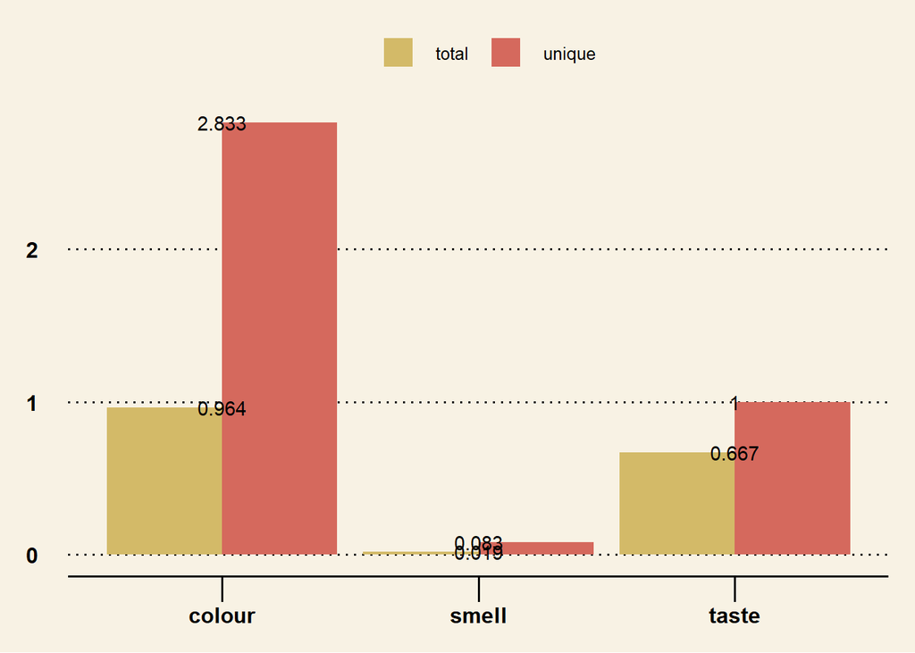

```r
ggplot(all_ratio,aes(type,number,fill=class))+geom_bar(stat="identity",position="dodge")+theme_wsj()+
scale_fill_wsj("rgby", "")+
theme(axis.ticks.length=unit(0.5,'cm'))+
guides(fill=guide_legend(title=NULL))+geom_text(aes(label=number))
```

As we can see, colour always has the highest ratio of domain-specific/source-based/evaluative/other terms for type and tokens. Generally speaking, the ratio of type is higher than that of token across all three domains, which means domian-specific unique terms are more common than in other categories.

Exemplar listing

```r
exe_listing<- read.xlsx('data_2.xlsx',sheetIndex=1)
exe_listing<-data.frame(lapply(exe_listing, function(v) {
  if (is.character(v)) return(tolower(v))
  else return(v)
}))
exe_listing
```

```
##          BITTER          SOUR      SALTY           SPICY        SWEET  STINKY
## 1        coffee          acid       salt          pepper        sugar   shoes
## 2     chocolate          acid        sea           onion        honey  armpit
## 3        coffee         lemon       tear          ginger        apple     egg
## 4  bitter melon          lime      bacon           chili       grapes    shit
## 5  bitter melon       kimichi     cheese          wasabi         pear  durian
## 6     green tea        pickle      sweat         mustard       cookie     egg
## 7       tabacco       vinegar        ham          pepper    ice cream     egg
## 8          beer       vinegar      sweat         mustard      dessert   sperm
## 9        coffee       vinegar       salt           chili        candy   socks
## 10      herring        pickle      sweat          pepper   strawberry   shoes
## 11     red wine        pickle      sweat           chili blood orange   sperm
## 12       coffee         lemon   crackers          ginger        candy   skunk
## 13    green tea       kimichi       tear          pepper        candy   skunk
## 14      vinegar         lemon        ham           chili        sugar  shrimp
```

[output cut: 101 more lines]

```r
new_listing<-c()
for (i in 1:length(colnames(exe_listing))) {
  new_listing<-c(new_listing,exe_listing[,i][!is.na(exe_listing[,i])])

}
new_listing<-data.frame(new_listing)
new_listing
```

```
##         new_listing
## 1            coffee
## 2         chocolate
## 3            coffee
## 4      bitter melon
## 5      bitter melon
## 6         green tea
## 7           tabacco
## 8              beer
## 9            coffee
## 10          herring
## 11         red wine
## 12           coffee
## 13        green tea
## 14          vinegar
```

[output cut: 288 more lines]

```r
fre_table<-new_listing%>%group_by(new_listing)%>%summarise(fre=length(new_listing))%>%arrange(desc(fre))
fre_table
```

```
## # A tibble: 90 x 2
##    new_listing   fre
##    <chr>       <int>
##  1 sweat           9
##  2 cheese          8
##  3 mustard         8
##  4 durian          7
##  5 garbage         7
##  6 candy           6
##  7 chili           6
##  8 chips           6
##  9 lemon           6
## 10 cake            5
## # ... with 80 more rows
```

```r
exe_listing_2<-exe_listing%>%mutate(Term="id")
exe_listing_2<-pivot_longer(exe_listing_2,cols = !Term)
exe_listing_2<-exe_listing_2[,2:3]
exe_listing_2
```

```
## # A tibble: 399 x 2
##    name   value
##    <chr>  <chr>
##  1 BITTER coffee
##  2 SOUR   acid
##  3 SALTY  salt
##  4 SPICY  pepper
##  5 SWEET  sugar
##  6 STINKY shoes
##  7 SMELLY shoes
##  8 BITTER chocolate
##  9 SOUR   acid
## 10 SALTY  sea
## # ... with 389 more rows
```

```r
exe_listing_2<-na.omit(exe_listing_2)
comparison1<-exe_listing_2%>%group_by(name)%>%summarise(total_n=length(name))
comparison2<-exe_listing_2%>%group_by(name)%>%summarise(unique_n=length(unique(value)))
comparison<-full_join(comparison2,comparison1,by="name")
comparison<-comparison%>%mutate("typetokenratio"=round(unique_n/total_n,3))
comparison
```

```
## # A tibble: 7 x 4
##   name   unique_n total_n typetokenratio
##   <chr>     <int>   <int>          <dbl>
## 1 BITTER       15      34          0.441
## 2 SALTY        16      45          0.356
## 3 SMELLY       16      37          0.432
## 4 SOUR         17      39          0.436
## 5 SPICY        12      38          0.316
## 6 STINKY       21      52          0.404
## 7 SWEET        22      57          0.386
```

```r
comparison1<-comparison1%>%mutate(class="total_n")%>%rename(number=total_n)
comparison2<-comparison2%>%mutate(class="unique_n")%>%rename(number=unique_n)
comparison_total<-rbind(comparison1,comparison2)
comparison_total
```

```
## # A tibble: 14 x 3
##    name   number class
##    <chr>   <int> <chr>
##  1 BITTER     34 total_n
##  2 SALTY      45 total_n
##  3 SMELLY     37 total_n
##  4 SOUR       39 total_n
##  5 SPICY      38 total_n
##  6 STINKY     52 total_n
##  7 SWEET      57 total_n
##  8 BITTER     15 unique_n
##  9 SALTY      16 unique_n
## 10 SMELLY     16 unique_n
## 11 SOUR       17 unique_n
## 12 SPICY      12 unique_n
## 13 STINKY     21 unique_n
## 14 SWEET      22 unique_n
```

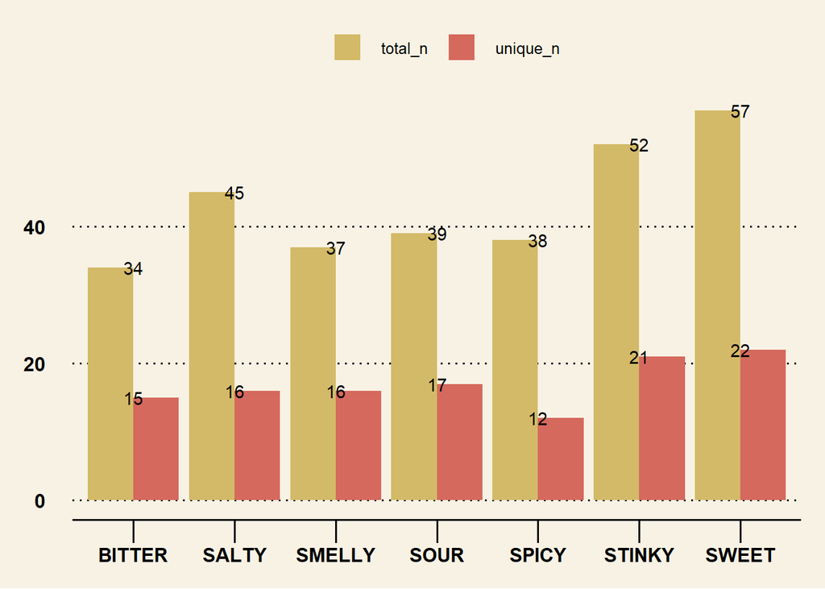

```r
ggplot(comparison_total,aes(name,number,fill=class))+geom_bar(stat="identity",position="dodge")+theme_wsj()+
scale_fill_wsj("rgby", "")+
theme(axis.ticks.length=unit(0.5,'cm'))+
guides(fill=guide_legend(title=NULL))+geom_text(aes(label=number))
```

As the bar chart above demonstrated, sweet examples are easiest for international students to come up with, because everyone enjoys sweet candies. However, I am a little bit curious about why people can also think of so many stinky terms. Maybe our environment is becoming worse. Meanwhile, the bitter terms are the last thing that international students would like to think of.(Here I just listed total terms people listed per domain,not on average)

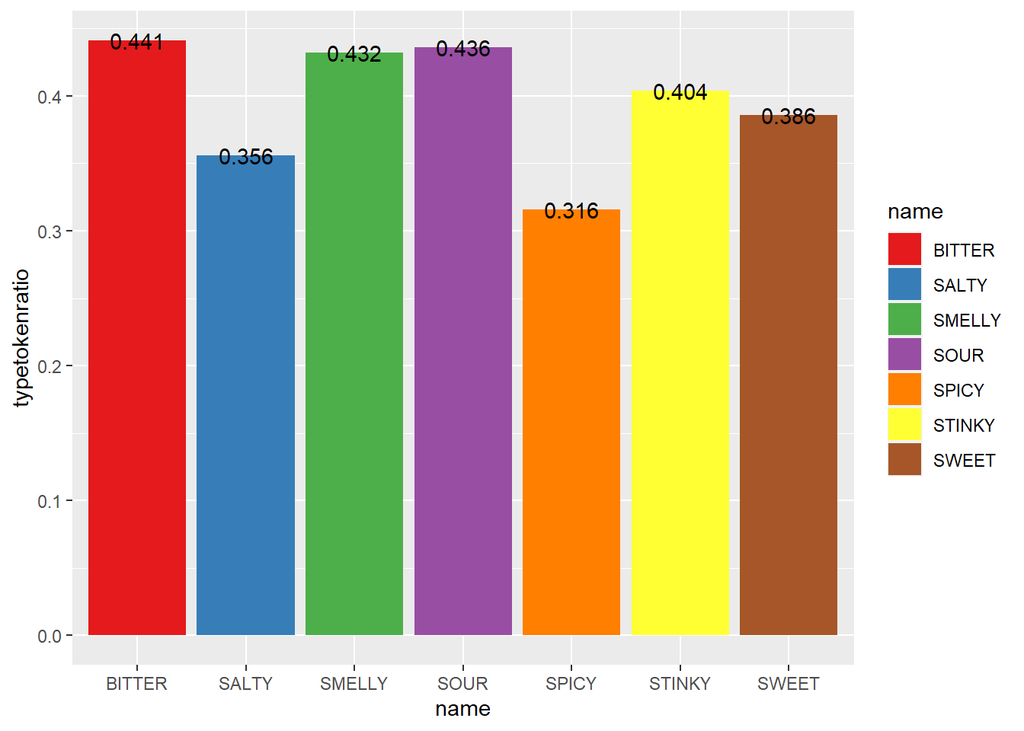

```r
ggplot(comparison,aes(x=name,y=typetokenratio,fill=name))+geom_bar(stat="identity",position="dodge")+geom_text(aes(label=typetokenratio))+scale_fill_brewer(palette = "Set1")
```

As the chart shows above, the type token ratios of each term are pretty close. Bitter, sour, and smelly are greater in lexical richness than other terms.

Similarity between two languages

I will choose Jaccard Index to calculate the similarity,because the math formula is quite handy and we just need calculate the set and union of two language data. The formula is shown as below: J(A,B) = |A intersection B| / |A union B|

```r
dutch_listing<- read.csv('dutchtasteexemplars.csv')
dutch_listing<-data.frame(lapply(dutch_listing, function(v) {
  if (is.character(v)) return(tolower(v))
  else return(v)
}))
dutch_listing
```

```
##      taste              dutch            english frequency      category
## 1    sweet              snoep              candy        32  source-based
## 2    sweet             suiker              sugar        23  source-based
## 3    sweet            aardbei         strawberry        10  source-based
## 4    sweet            chocola          chocolate         9  source-based
## 5    sweet          frisdrank         soft drink         6  source-based
## 6    sweet              fruit              fruit         6  source-based
## 7    sweet                ijs          ice cream         6  source-based
## 8    sweet              taart                pie         6  source-based
## 9    sweet             honing              honey         5  source-based
## 10   sweet               cola               coke         4  source-based
## 11   sweet               koek               cake         4  source-based
## 12   sweet            koekjes            cookies         4  source-based
## 13   sweet           limonade           lemonade         4  source-based
## 14   sweet             siroop              syrup         4  source-based
```

[output cut: 104 more lines]

```r
dutch_listing_wider<-dutch_listing%>%pivot_wider(names_from = taste,values_from = english)
dutch_listing_wider
```

```
## # A tibble: 117 x 8
##    dutch     frequency category     sweet      bitter sour  salty spicy
##    <chr>         <int> <chr>        <chr>      <chr>  <chr> <chr> <chr>
##  1 snoep            32 source-based candy      <NA>   <NA>  <NA>  <NA>
##  2 suiker           23 source-based sugar      <NA>   <NA>  <NA>  <NA>
##  3 aardbei          10 source-based strawberry <NA>   <NA>  <NA>  <NA>
##  4 chocola           9 source-based chocolate  <NA>   <NA>  <NA>  <NA>
##  5 frisdrank         6 source-based soft drink <NA>   <NA>  <NA>  <NA>
##  6 fruit             6 source-based fruit      <NA>   <NA>  <NA>  <NA>
##  7 ijs               6 source-based ice cream  <NA>   <NA>  <NA>  <NA>
##  8 taart             6 source-based pie        <NA>   <NA>  <NA>  <NA>
##  9 honing            5 source-based honey      <NA>   <NA>  <NA>  <NA>
## 10 cola              4 source-based coke       <NA>   <NA>  <NA>  <NA>
## # ... with 107 more rows
```

```r
dutch_sweet_v<-dutch_listing_wider$sweet[!is.na(dutch_listing_wider$sweet)]
english_sweet_v<-exe_listing$SWEET[!is.na(exe_listing$SWEET)]
sweet_intersection<-intersect(dutch_sweet_v,english_sweet_v)
sweet_union<-union(dutch_sweet_v,english_sweet_v)
sweet_similarity<-c("sweet_similarity",length(sweet_intersection)/length(sweet_union))
sweet_similarity
```

```
## [1] "sweet_similarity"  "0.209302325581395"
```

```r
dutch_bitter_v<-dutch_listing_wider$bitter[!is.na(dutch_listing_wider$bitter)]
english_bitter_v<-exe_listing$BITTER[!is.na(exe_listing$BITTER)]
bitter_intersection<-intersect(dutch_bitter_v,english_bitter_v)
bitter_union<-union(dutch_bitter_v,english_bitter_v)
bitter_similarity<-c("bitter_similarity",length(bitter_intersection)/length(bitter_union))
bitter_similarity
```

```
## [1] "bitter_similarity" "0.125"
```

```r
dutch_sour_v<-dutch_listing_wider$sour[!is.na(dutch_listing_wider$sour)]
english_sour_v<-exe_listing$SOUR[!is.na(exe_listing$SOUR)]
sour_intersection<-intersect(dutch_sour_v,english_sour_v)
sour_union<-union(dutch_sour_v,english_sour_v)
sour_similarity<-c("sour_similarity",length(sour_intersection)/length(sour_union))
sour_similarity
```

```
## [1] "sour_similarity"   "0.296296296296296"
```

```r
dutch_spicy_v<-dutch_listing_wider$spicy[!is.na(dutch_listing_wider$spicy)]
english_spicy_v<-exe_listing$SPICY[!is.na(exe_listing$SPICY)]
spicy_intersection<-intersect(dutch_spicy_v,english_spicy_v)
spicy_union<-union(dutch_spicy_v,english_spicy_v)
spicy_similarity<-c("spicy_similarity",length(spicy_intersection)/length(spicy_union))
spicy_similarity
```

```
## [1] "spicy_similarity"  "0.117647058823529"
```

```r
dutch_salty_v<-dutch_listing_wider$salty[!is.na(dutch_listing_wider$salty)]
english_salty_v<-exe_listing$SALTY[!is.na(exe_listing$SALTY)]
salty_intersection<-intersect(dutch_salty_v,english_salty_v)
salty_union<-union(dutch_salty_v,english_salty_v)
salty_similarity<-c("salty_similarity",length(salty_intersection)/length(salty_union))
salty_similarity
```

```
## [1] "salty_similarity"  "0.171428571428571"
```

```r
similarity_table<-rbind.data.frame(t(sweet_similarity),t(bitter_similarity),t(sour_similarity),t(spicy_similarity),t(salty_similarity))
similarity_table<-similarity_table%>%rename(class=V1)%>%rename(similarity_index=V2)
similarity_table$similarity_index<-round(as.numeric(similarity_table$similarity_index),3)
similarity_table
```

```
##               class similarity_index
## 1  sweet_similarity            0.209
## 2 bitter_similarity            0.125
## 3   sour_similarity            0.296
## 4  spicy_similarity            0.118
## 5  salty_similarity            0.171
```

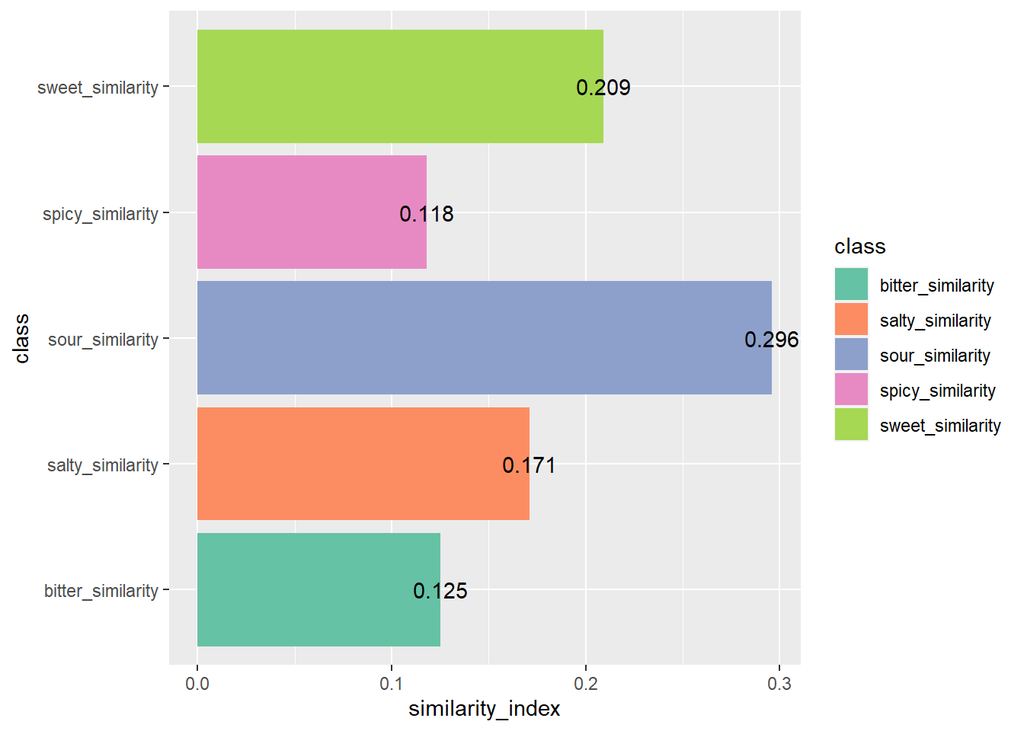

```r
ggplot(similarity_table,aes(x=class,y=similarity_index,fill=class))+geom_bar(stat="identity",position="dodge")+geom_text(aes(label=similarity_index))+scale_fill_brewer(palette = "Set2")+coord_flip()
```

As the graph above showed, the sour term is the most similar one among all the taste terms between English and Dutch, while the spicy term is least similar. I assume international students always have different spicy foods from Dutch students.